# Installing R under Windows

Abstract

“Installing R under Windows” published in R News.

Very few Windows users will have ever experienced compiling a large system, as binary installations of Windows software are universal. Further, users are used to installing software by a point-and-click interface with a minimum of reading of instructions, most often none. The expectation is

Insert the CD.

If it doesn’t auto-run, double-click on a file called `Setup.exe` in the top directory.

Go through a few ‘Wizard’ pages, then watch a progress bar as files are installed, then click on Finish.

Contrast this with ‘untar the sources, run `./configure`, make then make install’. Each in its own way is simple, but it is really horses for courses.

Every since Guido Masarotto put out a version of R for Windows as a set of zip files we have been looking for a way to install R in a style that experienced Windows users will find natural. At last we believe we have found one.

When I first looked at this a couple of years ago most packages (even Open Source ones) used a commercial installer such as InstallShield or Wise. Although I had a copy of InstallShield, I was put off by its size, complexity and the experiences I gleaned, notably from Fabrice Popineau with his `fptex` installation.

Shortly afterwards, MicroSoft introduced their own installer for their Office 2000 suite. This works in almost the same way, except that one double-clicks on a file with extension `.msi`. There is a development kit for this installer and I had expected it to become the installer of choice, but it seems rarely used. (The Perl and now Tcl ports to Windows do use it.) That makes one of its disadvantages serious: unless you have a current version of Windows (ME or 2000) you need to download the installer `InstMsi.exe`, which is around 1.5Mb and whose installation needs privileges an ordinary user may not have.

In May 1999 I decided to write a simple installer, `rwinst.exe`, using the GraphApp toolkit that Guido had used to write the R for Windows GUI, and this has been in use since. But it was not ideal, for

- It did not use a completely standard ‘look-and-feel’.
- It was hard to maintain, and mistakes in an installer are ‘mission-critical’.
- Users found it hard to cope with needing several files to do the installation.

The prospect of *recommended* packages at version 1.3.0 was going to require twice as many files, and forced a re-think in early 2001. I had earlier looked at Inno Setup by Jordan Russell (www.jrsoftware.org)

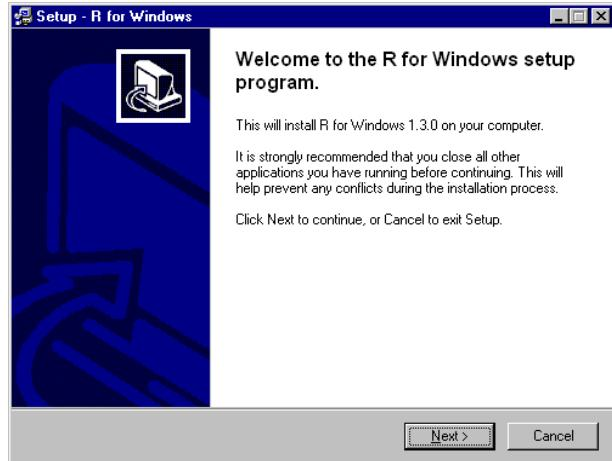

$a$ The ‘welcome’ screen

[figure not shown]

$b$ The licence – GPL2 of course

[figure not shown]

$c$ Choose the installation folder

[figure not shown]

$d$ Select components as required

[figure not shown]

$e$ There is a list of standard selections, plus ‘custom’

[figure not shown]

$f$ Choose a group name for the Start menu

[figure not shown]

$g$ Do you want a desktop icon?

[figure not shown]

$h$ Installing the files and had found it too limited. However, an enhanced version 2 was by then in beta release and was used to make an alternative installer for R 1.2.3. Inno Setup 2 is now released and has been adopted for the recommended installers for R 1.3.0. The figures show the installation sequence using SetupR.exe for 1.3.0. Note that there is a fair degree of control but with sensible defaults. For example, the commercial installers do not usually offer the option **not** to add to the start menu, nor to add a desktop icon (and that is labelled by the R version number).

The SetupR.exe installation is a single file of about 15Mb, which can conveniently be distributed on CD-R or downloaded (over a fast enough Internet connection).

One issue that had been a concern was that it is thought that some users need to install R from floppies, and the .zip files had been designed where possible[^1] to fit on a single floppy. How much demand there was/is is hard to gauge, and such users almost by definition are unlikely to be fairly represented by email contact. As R grew, maintaining a division into floppy-sized pieces became harder, and needed constant vigilance. Fortunately Inno Setup provided a simple option to produce (exactly) floppy-sized pieces, and we have an alternative distribution consisting of miniR.exe and miniR-1.bin which fit on one floppy, and mini-2.bin to mini-6.bin which fit on five further floppies. The six floppies are very full, and doubtless the next release will need seven.

Inno Setup is a Delphi program which is freely available (including source). It is programmed by a script of instructions. For a project the size of R that script needs to be a few thousand lines, but is generated automatically by a Perl script from the distribution files. I had a workable installer running in a couple of hours, have spent less than a day on it in total, and future maintenance of this installer should be a much easier task

### Uninstalling

Surely you wouldn’t want to remove something as useful as R?

One good reason to remove R is to clear space before upgrading to a new version. In the past the only way to do this was to delete the whole directory containing R, say `c:\R\rw1021`. That did remove everything, as R touched nothing else (it did not use the Registry nor the system directories), but it would also wipe out any customizations the user had made, as well as all the add-on packages installed in `c:\R\rw1021\library`.

Inno Setup automatically provides an uninstaller, and an R installation made with setupR.exe or miniR.exe can be removed via the R group on the Start menu, from the Control Panel[^2] or by running Uninst.exe in the top directory of the installation. This does only uninstall the files it installed, so that added packages are left. It also removes the Registry entries it set.

This makes upgrading easy. Just uninstall the old version, install the new one and move the added packages across to `c:\R\rw1030\library` (say). **Note:** some packages may need to be updated to work with new versions of R, so as a final step run `update.packages()`. Which brings us to …

### Installing packages

[figure not shown]

Other items on that menu provide shortcuts to `library()` and `update.packages()`.

[^1]: this was never possible for the .zip file containing the 4.6Mb PDF version of the reference manual.
[^2]: for sufficiently privileged users only